# Challenge 2

Pablo Barbera

May 19, 2016

#### Supervised machine learning

Write code in R that help you answer the following questions. As in the previous challenge, we’ll be working with a dataset that contains all the tweets sent by Donald Trump, Ted Cruz, Hillary Clinton, and Bernie Sanders during the 2016 primary election campaign.

1. After reading a candidate, pick a candidate and create a dummy that indicates whether each tweet was sent by that candidate. We’ll be trying to see if we can build a classifier to predict whether a tweet is coming from a given candidate.

```r
tweets <- read.csv('../datasets/candidate-tweets.csv', stringsAsFactors=F)
tweets$trump <- ifelse(tweets$screen_name=="realDonaldTrump", 1, 0)
tweets$text <- gsub('https?://t.co/[A-Za-z0-9]+', '', tweets$text)
```

2. Create a training and test set, with 80% and 20%, respectively.

```r
set.seed(123)
training <- sample(1:nrow(tweets), floor(.80 * nrow(tweets)))
test <- (1:nrow(tweets))[1:nrow(tweets) %in% training == FALSE]
```

3. Construct the DFM. You may want to experiment with different preprocessing techniques until you achieve better performance.

```r
library(quanteda)
twcorpus <- corpus(tweets$text)
twdfm <- dfm(twcorpus, ignoredFeatures=c(
  stopwords("english"), "rt", "amp", "can", "u", "h", "t"), ngram=c(1,2))
```

```
## Creating a dfm from a corpus ...
##    ... lowercasing
##    ... tokenizing
##    ... indexing documents: 26,735 documents
##    ... indexing features: 187,560 feature types
##    ... removed 85,131 features, from 180 supplied (glob) feature types
##    ... created a 26735 x 102430 sparse dfm
##    ... complete.
## Elapsed time: 7.432 seconds.
```

```r
twdfm <- trim(twdfm, minDoc = 2)
```

```
## Removing features occurring in fewer than 2 documents: 76463
```

[figure not shown]

```r
plot(twdfm, rot.per=0, scale=c(3.5, .75), max.words=100)
```

4. Now run the classifier. Then, compute the accuracy.

```r
library(glmnet)
require(doMC)
```

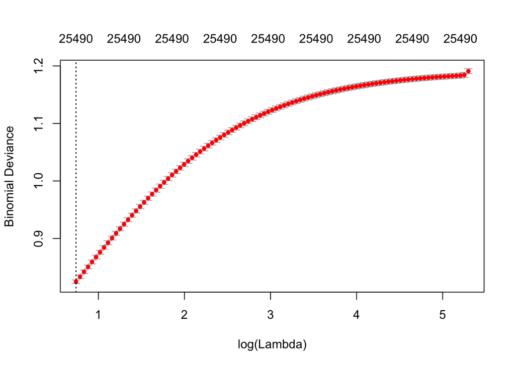

```r
registerDoMC(cores=3)
ridge <- cv.glmnet(twdfm[training,], tweets$trump[training],
    family="binomial", alpha=0, nfolds=5, parallel=TRUE,
    type.measure="deviance")
plot(ridge)
```

```r
## function to compute accuracy
accuracy <- function(ypred, y){
    tab <- table(ypred, y)
    return(sum(diag(tab))/sum(tab))
}
# function to compute precision
precision <- function(ypred, y){
    tab <- table(ypred, y)
    return((tab[2,2])/(tab[2,1]+tab[2,2]))
}
# function to compute recall
recall <- function(ypred, y){
    tab <- table(ypred, y)
    return(tab[2,2]/(tab[1,2]+tab[2,2]))
}
# computing predicted values
preds <- predict(ridge, twdfm[test,], type="response") > mean(tweets$trump[test])
# confusion matrix
table(preds, tweets$trump[test])
```

```
##
## preds      0    1
##   FALSE 3484   53
##   TRUE   370 1440
```

```r
# performance metrics
accuracy(preds, tweets$trump[test])
```

```
## [1] 0.9208902
```

```r
precision(preds, tweets$trump[test])
```

```
## [1] 0.7955801
```

```r
recall(preds, tweets$trump[test])
```

```
## [1] 0.964501
```

5. Identify the features that better predict that tweets were sent by this candidate. What do you learn?

```r
# from the different values of lambda, let's pick the best one
best.lambda <- which(ridge$lambda==ridge$lambda.min)
beta <- ridge$glmnet.fit$beta[,best.lambda]
head(beta)
```

```
##         @tedcruz @realdonaldtrump             will            trump
##      -0.09582390       0.22057849       0.06125355       0.13169817
##          hillary            great
##      -0.04955145       0.12137702
```

```r
## identifying predictive features
df <- data.frame(coef = as.numeric(beta),
                word = names(beta), stringsAsFactors=F)

df <- df[order(df$coef),]
head(df[,c("coef", "word")], n=30)
```

```
##             coef                     word
## 23990 -0.1874657                  narrows
## 11809 -0.1738446         trump_impression
## 25670 -0.1659632        hate_#supermonday
## 23624 -0.1640867      establishment_trump
## 21568 -0.1615151              times_trump
## 21567 -0.1610681                 selected
## 12536 -0.1570604                pressures
## 9799  -0.1565509            america_whole
## 20431 -0.1544120                   s_lead
## 22122 -0.1535334               third_term
## 13069 -0.1510762         trump_#gopdebate
## 21267 -0.1501025                extremist
## 22510 -0.1491067                  top_ten
## 23141 -0.1482455              will_triple
```

[output cut: 16 more lines]

```r
paste(df$word[1:30], collapse=", ")
```

```
## [1] "narrows, trump_impression, hate_#supermonday, establishment_trump, times_trump, selected, pressures, america_whole, s_lead, third_term, trump_#gopdebate, extremist, top_ten, will_triple, shows_ted, leads_national, new_senator, phasing, bush_say, hope_trump, beating_@realdonaldtrump, trump_lo…
```

```r
df <- df[order(df$coef, decreasing=TRUE),]
head(df[,c("coef", "word")], n=30)
```

```
##            coef                 word
## 15493 0.3171688             measured
## 15313 0.3160092                deeds
## 18590 0.3152547             get_home
## 17791 0.3140701           get_caught
## 11233 0.3126475      @drudge_report_
## 15079 0.3115328          just_opened
## 16805 0.3111441           tragic_day
## 17532 0.3104802           daily_mail
## 17990 0.3103536         ridiculously
## 15168 0.3078378         commencement
## 6922  0.3069367         #trumpadvice
## 11256 0.3064502            full_clip
## 15386 0.3040731                  tmw
## 18278 0.3029554         francis_tear
```

[output cut: 16 more lines]

```r
paste(df$word[1:30], collapse=", ")
```

```
## [1] "measured, deeds, get_home, get_caught, @drudge_report_, just_opened, tragic_day, daily_mail, ridiculously, commencement, #trumpadvice, full_clip, tmw, francis_tear, support_south, peggy, wisconsin_#wiprimary, terrible_deal, @drudgereport, cruz_put, @trumpwaikiki's, wow_big, #maga, homeland, …
```

BONUS. Train wordscores in the Congress dataset we just used and then try to see how well it predicts the ideology of the presidential candidates